# Diagnostics for linear models

13 April 2026

## Goals for today

- Recognize that diagnostic checks are necessary for any model
- Learn how to check for constant variance, normally distributed errors, and autocorrelation
- Learn how to check for outlying or influential observations

## Model structure

Our focus here is on linear models, and we saw previously that we can use linear models to approximate nonlinear functions

The specific form of the model should reflect our understanding of the system and any particular hypotheses we’d like to test

## Model diagnostics

We have seen how to fit models, estimate parameters with uncertainty, and conduct hypothesis tests

All of these rely on a number of assumptions about

- our model (its structure is correct)
- the errors (independent, equal variance, normally distributed)
- observations and predictors (no undue influence)

## Checking error assumptions

So far our models have assumed the errors to be *independent and identically distributed* (IID)

What exactly does this mean?

## Checking error assumptions

### Constant variance

Let’s begin with the notion of “identically distributed”, which suggests no change in the variance across the model space

For example, if our errors are assumed to be normally distributed, such that

\[ e_i \sim \text{N}(0, \sigma^2) ~ \Rightarrow ~ \boldsymbol{e} \sim \text{MVN}(\mathbf{0}, \sigma^2 \mathbf{I}) \]

then we expect no difference in \(\sigma^2\) among any of the \(e_i\)

## Checking error assumptions

### Constant variance

To check this assumption, we can plot our estimates \(e_i = e_i = y- \hat{y}\) against our fitted values \(\hat{y}_i\) and look for any patterns

## Checking error assumptions

### Constant variance

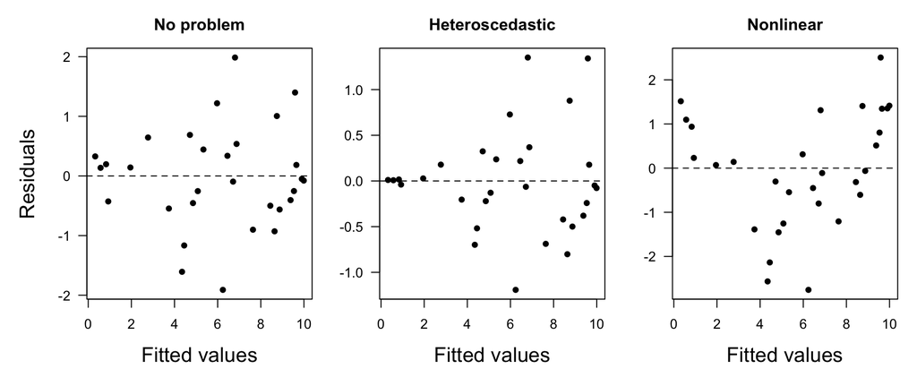

## Checking error assumptions

### Constant variance

For a finer resolution, we can also plot \(\sqrt{| e_i |}\) against our fitted values \(\hat{y}_i\) and look for any patterns

The distribution of \(| e_i |\) is a skewed half-normal on the positive interval; the square-root transformation makes them less skewed

## Checking error assumptions

### Constant variance

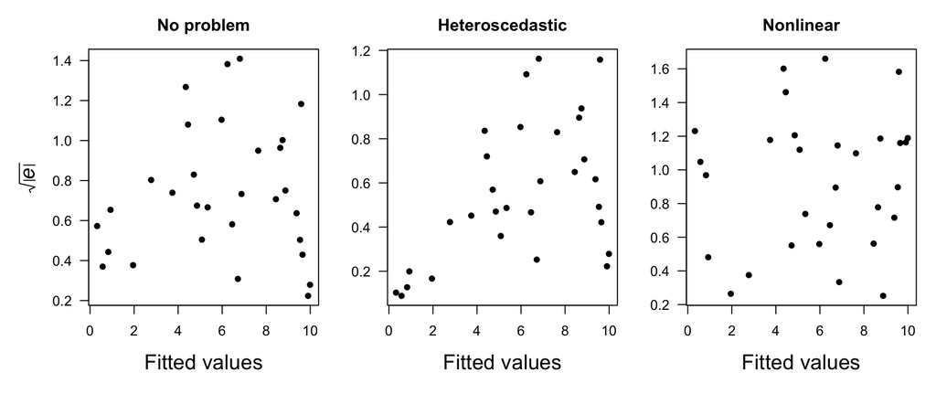

## Checking error assumptions

### Constant variance

We can formally test the assumption of homogeneous variance via *Levene’s Test*, which compares the absolute values of the residuals among \(j\) groups of data

\[ Z_{ij} = \left| y_{ij} - \hat{y}_j \right| \]

Levene’s test is a one-way ANOVA of the residuals with

\[ H_0: ~ \sigma^2_1 = \sigma^2_2 = \dots = \sigma^2_k \]

## Checking error assumptions

### Constant variance

The statistic for *Levene’s Test* is

\[ W=\frac{(n-k)}{(k-1)} \cdot \frac{\sum_{j=1}^{k} n_{j}\left(Z_{j} - \bar{Z} \right)^{2}}{\sum_{j=1}^{k} \sum_{i=1}^{n_{j}} \left( Z_{i j} - \bar{Z_{i}} \right)^{2}} \]

The test statistic \(W\) is approximately \(F\)-distributed with \(k-1\) and \(n-k\) degrees of freedom

## Checking error assumptions

Levene’s Test is easy to compute in **R**

```r
## split residuals (ee) into 2 groups: less than and greater than the median
g1 <- ee[ee < median(ee)]
g2 <- ee[ee > median(ee)]
## Levene's Test
var.test(g1, g2)
```

```
##
##  F test to compare two variances
##
## data:  g1 and g2
## F = 0.90486, num df = 14, denom df = 14, p-value = 0.8543
## alternative hypothesis: true ratio of variances is not equal to 1
## 95 percent confidence interval:
##  0.3037877 2.6951999
## sample estimates:
## ratio of variances
##          0.9048584
```

## Checking error assumptions

### Constant variance

What can we do if we find evidence of heteroscedasticity?

Try a transformation or weighted least squares, which we will see later this week

## Checking error assumptions

### Residuals vs other predictors

We can also plot the residuals against any potential predictors that were *not* included in the model

If we see a (linear) pattern, then consider including that predictor in a new model

## Checking error assumptions

### Residuals vs other predictors for \(y_i = \alpha + \beta x_{1,i} + e_i\)

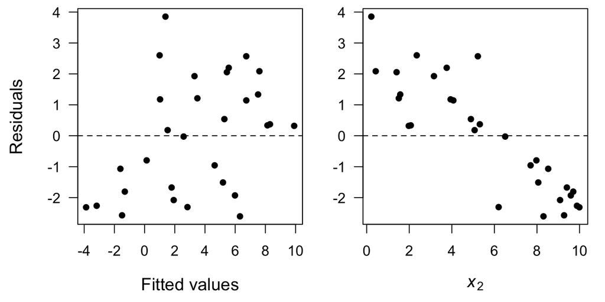

## Checking error assumptions

### Normality

We seek a method for assessing whether our residuals are indeed normally distributed

The easiest way is via a so-called \(Q\)-\(Q\) plot (for quantile-quantile)

## Checking error assumptions

### Expected quantiles for \(e \sim \text{N}(0,1)\)

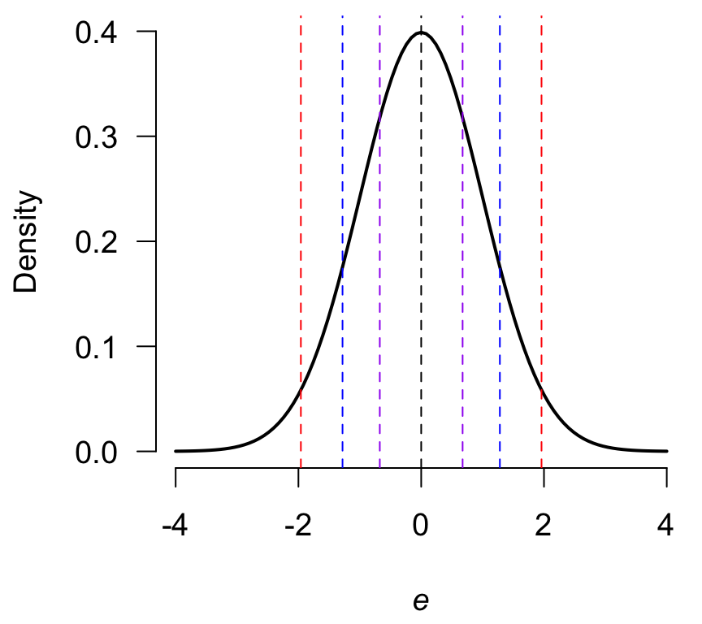

## Checking error assumptions

### Heavy-tailed (*leptokurtic*)

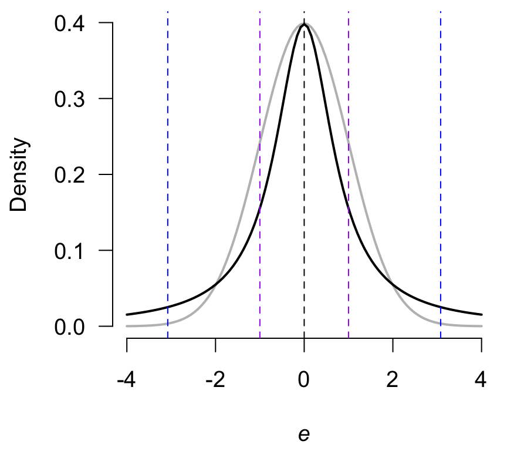

## Checking error assumptions

### Short-tailed (*platykurtic*)

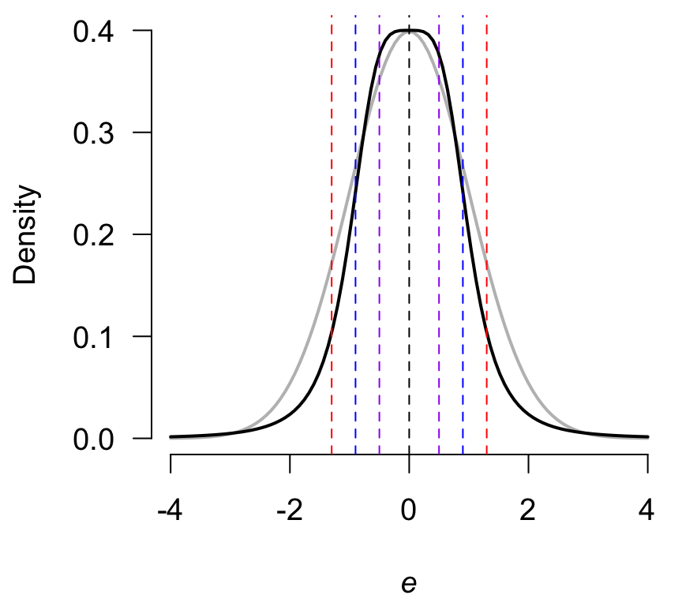

## Checking error assumptions

### \(Q\)-\(Q\) plots via `qqnorm(x)` in **R**

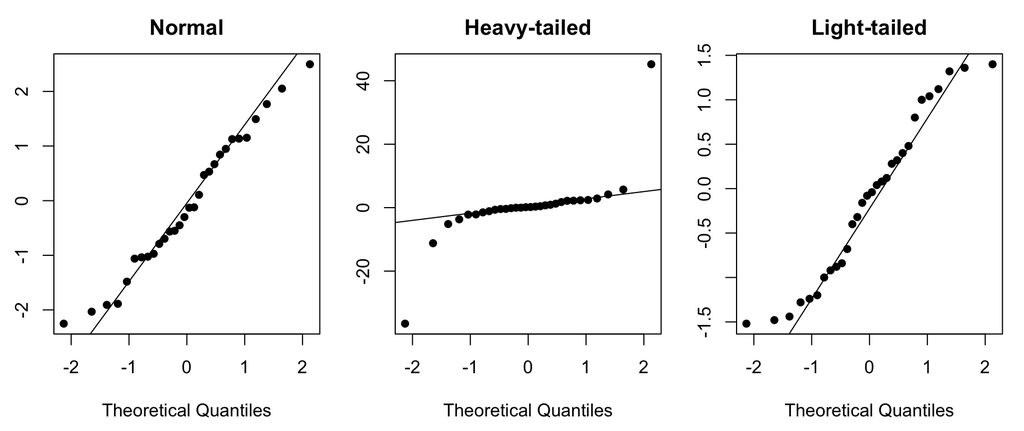

## Correlated errors

One component of *IID* errors is “independent”

This means we expect no correlation among any of the errors

## Correlated errors

We might expect to find correlated errors when working with

- Temporal data
- Spatial data
- Blocked data

## Correlated errors

Consider a model for tree growth as a function of temperature

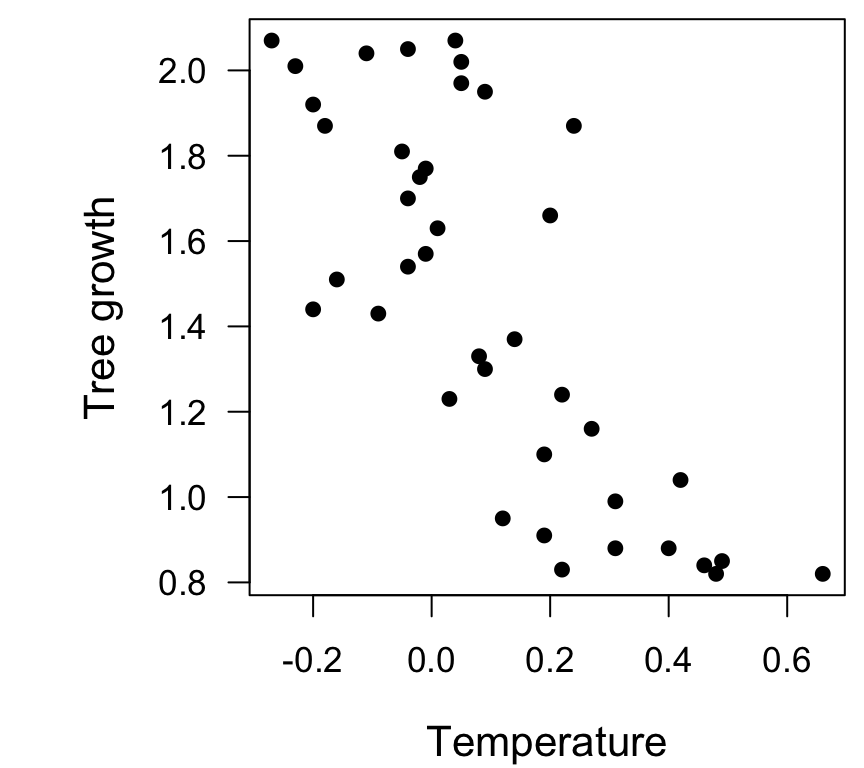

## Correlated errors

Closer examination of the residuals reveals a problem: correlated errors

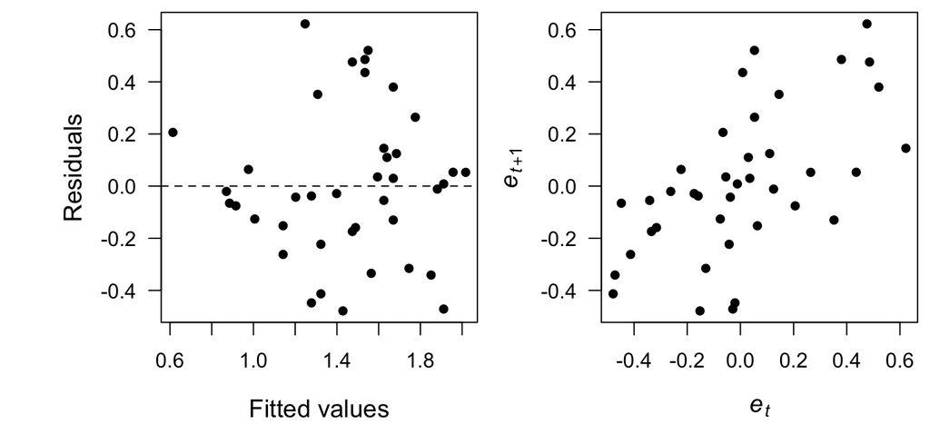

## Correlated errors

We can estimate the *autocorrelation function* in **R** with `acf()`

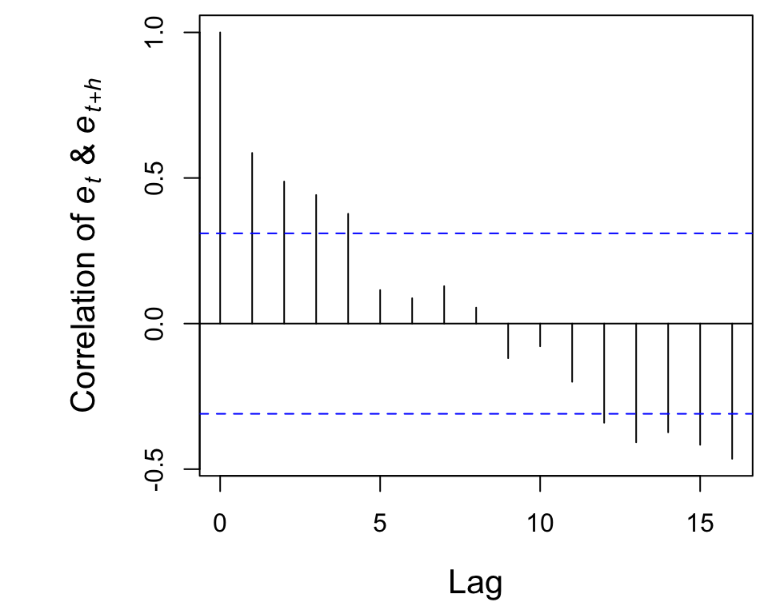

## QUESTIONS

## Unusual observations

### Outliers

It is often the case that one or more data points do not fit our model well

We refer to these as *outliers*

## Unusual observations

### Influence

Some outliers affect the fit of the model

We refer to these as *influential* observations

## Unusual observations

### Leverage points

*Leverage points* are extreme in the predictor \((X)\) space

They may or may not affect model fit

## Unusual observations

### Examples

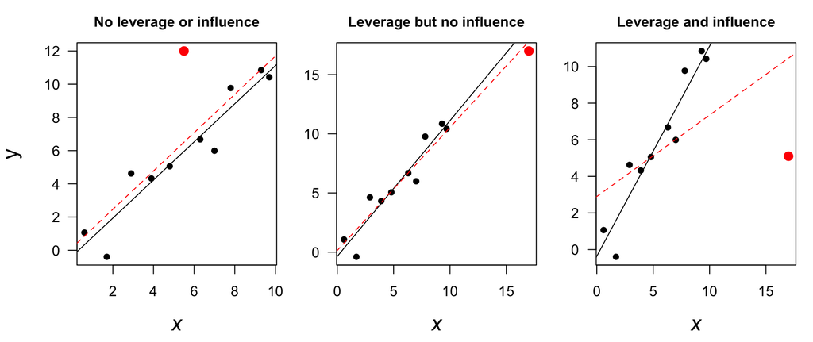

## Residual (error) variance

We said previously that

\(\text{var}(e_i) = \sigma^2\)

## Leverage and residual variance

We said previously that

\(\text{var}(e_i) = \sigma^2\)

In a regression context it becomes

\(\text{var}(e_i) = \sigma^2(1 - h_i)\)

where \(h_i\) is the leverage of observation (datum) \(i\)

## What are leverages?

Remember the “hat matrix” \((\mathbf{H})\)?

The values along the diagonal \(\color{blue}{h_{i,i}}\) are the leverages

\[ \mathbf{H} = \begin{bmatrix} \color{blue}{ h_{1,1}} & h_{1,2} & \dots & h_{1,n} \\ h_{2,1} & \color{blue}{h_{2,2}} & \dots & h_{2,n} \\ \vdots & \vdots & \color{blue}{\ddots} & \vdots \\ h_{n,1} & h_{n,2} & \dots & \color{blue}{h_{n,n}} \end{bmatrix} \]

with \(\color{blue}{h_{i,i}} \leq 1\); we’ll simply \(h_{i,i}\) to be \(h_i\)

## Leverages and residual variance

So given that

\(\text{Var}(e_i) = \sigma^2 (1 - h_i)\) and \({h_i} \leq 1\)

What happens as \(h_i \rightarrow 1\)?

## Leverages and residual variance

So given that

\(\text{Var}(e_i) = \sigma^2 (1 - h_i)\) and \({h_i} \leq 1\)

What happens as \(h_i \rightarrow 1\)?

Large \(h_i\) lead to small variances of \(e_i\) & hence \(\hat{y}_i \approx y_i\)

## Unusual observations

### Examples

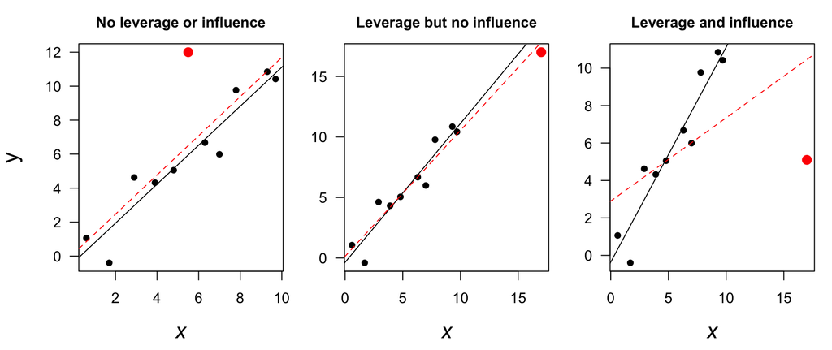

## Identifying leverage points

\(\mathbf{H}\) has dimensions \(n \times n\) and

\[ \text{trace}(\mathbf{H}) = \sum_{i = 1}^n h_i \]

Thus, on average we should expect that \(\bar{h}_i = \frac{k}{n}\)

Any \(h_i > \frac{2 k}{n}\) deserve closer inspection

## Identifying leverage points

We can easily compute the \(h_i\) in **R** via the function `hatvalues()`

```r
## leverages of points in middle plot on slide 37
hat_values <- hatvalues(m2)
## threshold value for h_i ~= 0.36
threshold <- 2 * (2 / length(hat_values))
## are any h_ii > threshold?
hat_values > threshold
```

```
##     1     2     3     4     5     6     7     8     9    10    11
## FALSE FALSE FALSE FALSE FALSE FALSE FALSE FALSE FALSE FALSE  TRUE
```

## Identifying leverage points

### via a half-normal plot*

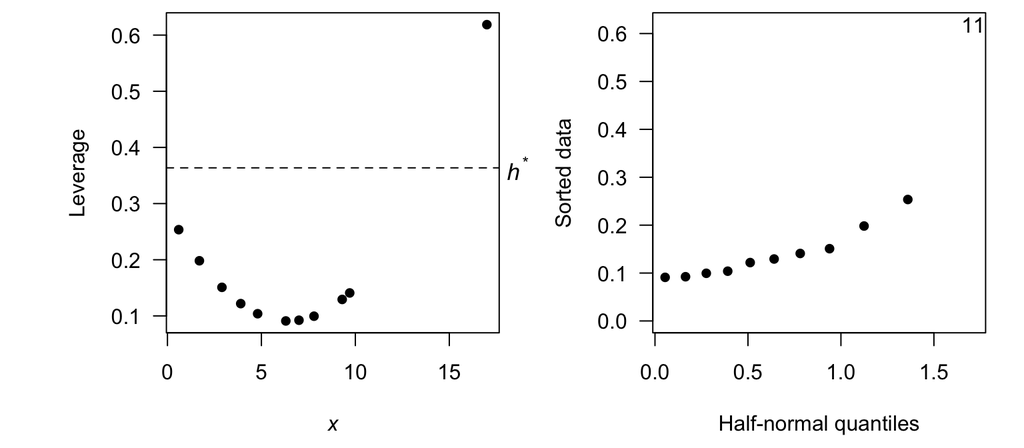

*see `.Rmd` file for R code to do this

## Using leverage to standardize residuals

We can use the leverages to scale the residuals so their variance is 1

\[ r_i = \frac{e_i}{\hat{\sigma} \sqrt{1 - h_i} } \]

Doing so allows for easy examination via \(Q\)-\(Q\) plots because the \(r_i\) should lie on the 1:1 line

## Using leverage to standardize residuals

Standardized residuals from the high leverage example

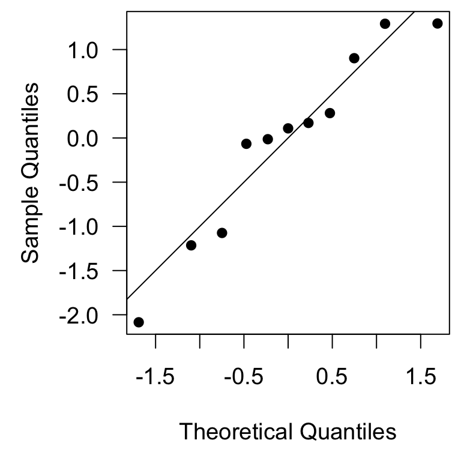

## Unusual observations

### Identifying outliers

One way to detect outliers is to estimate \(n\) different models where we exclude one data point from each model

## Unusual observations

### Identifying outliers

One way to detect outliers is to estimate \(n\) different models where we exclude one data point from each model

More formally we have

\[ \hat{\mathbf{y}}_{(i)} = \mathbf{X}_{(i)} \hat{\boldsymbol{\beta}}_{(i)} \]

where \((i)\) indicates that the \(i\)<sup>th</sup> datum has been omitted

If \(y_{i} - \hat{y}_{(i)}\) is large, then observation \(i\) is an outlier

## Unusual observations

### Identifying outliers

To evaluate the size of particular outlier we need to scale the residuals

This is similar to scaling a parameter estimate by its standard deviation to test model hypotheses, with

\[ t_i = \frac{\beta_i}{\text{SE} \left( \beta_i \right)} \]

and we compare it to a \(t\)-distribution with \(n - k\) degrees of freedom

## Unusual observations

### Identifying outliers

It turns out that the variance of the difference \(y_{i} - \hat{y}_{(i)}\) is just like that for a prediction interval

\[ \widehat{\text{Var}} \left( y_{i}-\hat{y}_{(i)} \right) = \hat{\sigma}_{(i)}^{2} \left( 1 + \mathbf{X}_{i}^{\top} \left( \mathbf{X}_{(i)}^{\top} \mathbf{X}_{(i)} \right)^{-1} \mathbf{X}_{i} \right) \]

## Unusual observations

### Identifying outliers

We can now compute the “studentized” (scaled) residuals as

\[ t_i = \frac{y_{i} - \hat{y}_{(i)}}{ \hat{\sigma}_{(i)} \sqrt{ 1 + \mathbf{X}_{i}^{\top} \left( \mathbf{X}_{(i)}^{\top} \mathbf{X}_{(i)} \right)^{-1} \mathbf{X}_{i} } } \]

which are distributed as a \(t\) distribution with \(n - k - 1\) df

## Unusual observations

### Identifying outliers

There is an easier way to do this without fitting \(n\) different models

Instead, we can define

\[ t_i = \frac{y_{i} - \hat{y}_{(i)}}{ \hat{\sigma}_{(i)} \sqrt{ 1 - h_i } } = e_i \sqrt{ \frac{n - k - 1}{n - k - e_i^2} } \]

where \(e_i\) is a residual based on a model that includes *all* of the data

## Unusual observations

### Identifying outliers

Some points to consider

- Two or more outliers next to each other can hide each other
- An outlier in one model may not be an outlier in another
- The error distribution may not be normal and so larger residuals may be expected
- Individual outliers are usually much less of a problem in larger datasets

## Unusual observations

### Identifying outliers

What can be done about outliers?

- Check for a data-entry error
- Examine the physical context — why did it happen?
- Exclude the point from the analysis but try reincluding it later if the model is changed
- Consider using “robust regression” (more later)
- Be wary of automatic discarding of outliers

## Unusual observations

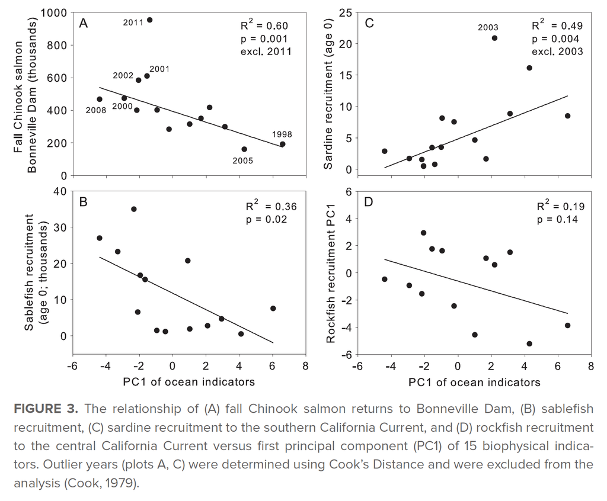

[Peterson et al (2014)](https://www.jstor.org/stable/24862214)

## Unusual observations

### Influential observations

Influential observations might not be outliers nor have high leverage, but we want to identify them

Cook’s Distance \((D)\) is a popular choice, where

\[ D_i = e_i^2 \frac{1}{k} \left( \frac{h_i}{1 - h_i} \right) \]

\(D_i\) scales the errors by their \(df\) and leverage

## Unusual observations

We can evaluate Cook’s \(D\) with a half-normal plot

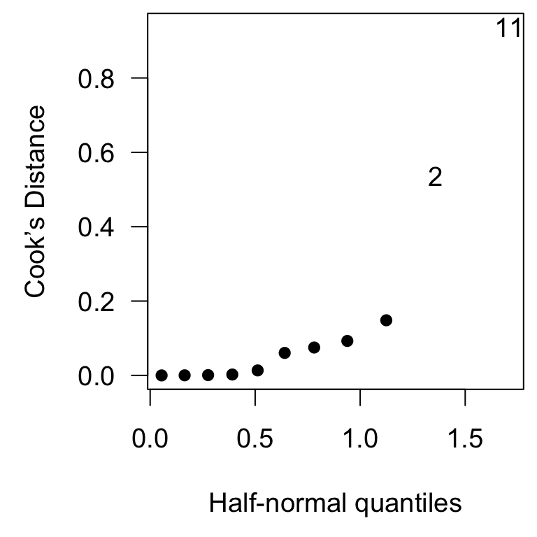

## Summary

When fitting linear models via least squares we make several assumptions about our model

## Summary

The importance of our assumptions can be ranked as

1. Systematic form of the model

If we get this wrong, explanations & predictions will be off

## Summary

The importance of our assumptions can be ranked as

1. Systematic form of the model
2. Independence of errors

Dependence (correlation) among errors means there is less info in the data than the sample size suggests

## Summary

The importance of our assumptions can be ranked as

1. Systematic form of the model
2. Independence of errors
3. Non-constant variance

This may affect inference and confidence/prediction intervals

## Summary

The importance of our assumptions can be ranked as

1. Systematic form of the model
2. Independence of errors
3. Non-constant variance
4. Normality of errors

This is less of a concern as sample size increases